# OLWTEF

# Chapter 25: Who was the last king of Scotland? African independence struggles

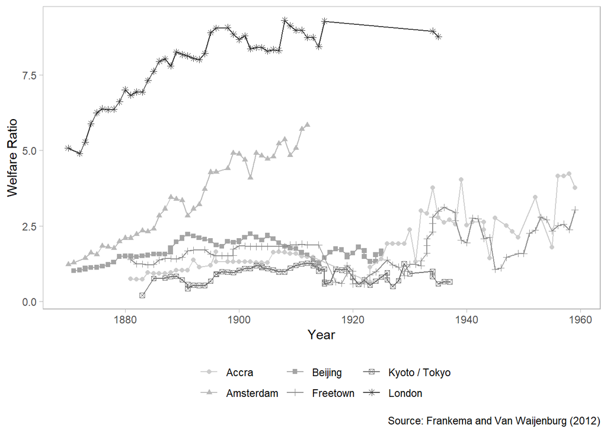

Colour

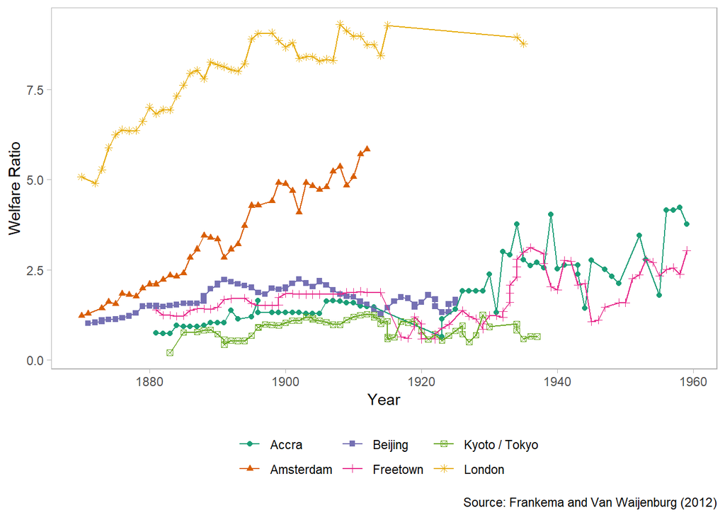

### Chapter 28: Why do the Japanese play rugby? The rise of the East Asian economies

Knowledge capital accounts for apparent growth mysteries in East Asia and Latin America B&W

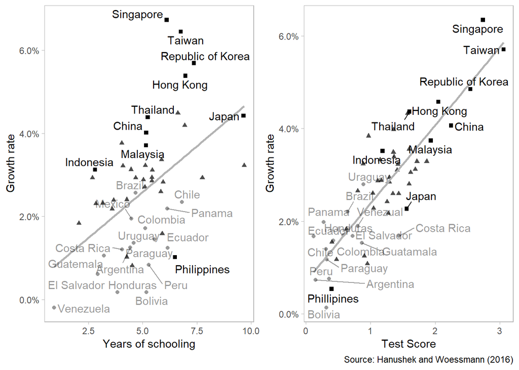

Colour

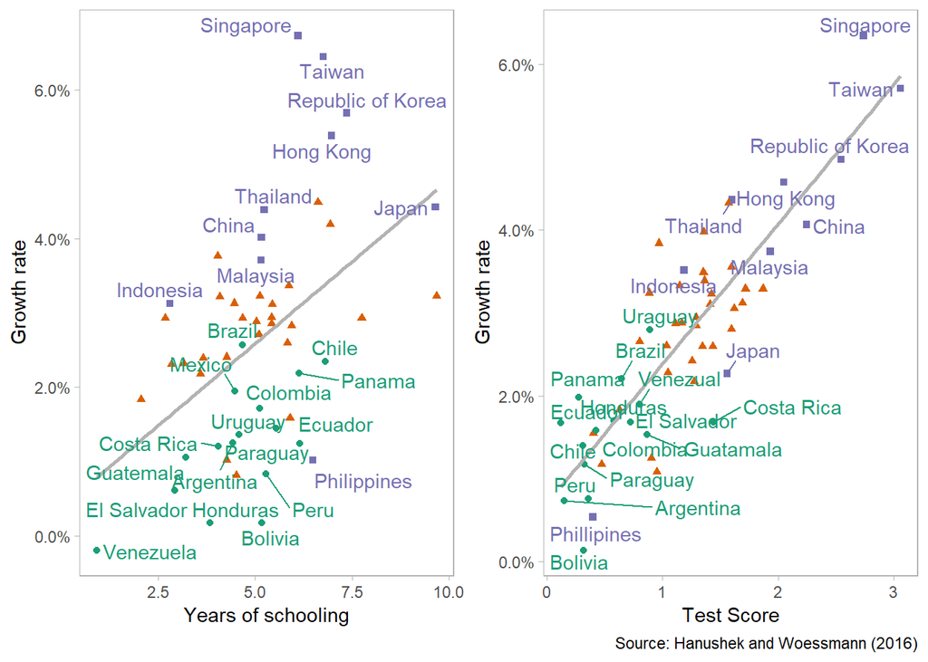

# Chapter 29: What do Lego and the greatest invention of the twentieth century have in commons? The second era of globalization

### The value of global exports

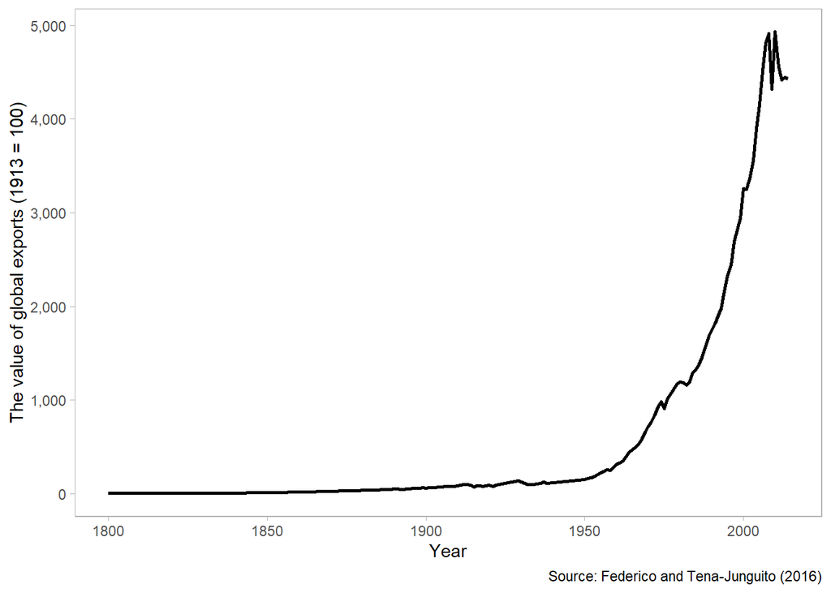

# Chapter 30: What is funny about Moore’s law? ICT and the Fourth Industrial Revolution

# Transistor count

```
## # A tibble: 42 x 2
##    designer     n
##    <chr>    <int>
##  1 Intel       63
##  2 AMD         18
##  3 IBM         13
##  4 Apple       12
##  5 Fujitsu     10
##  6 Motorola     8
##  7 Qualcomm     8
##  8 Huawei       6
##  9 Acorn        4
## 10 Hitachi      4
## # ... with 32 more rows
```

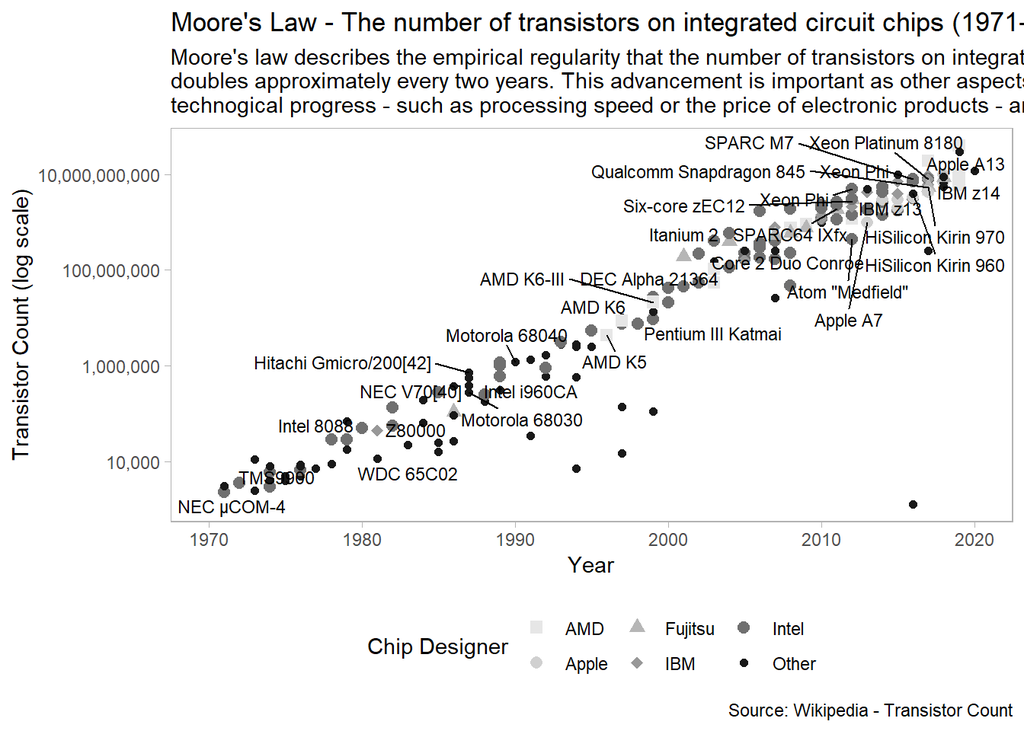

Moore’s Law: Without title and explanation

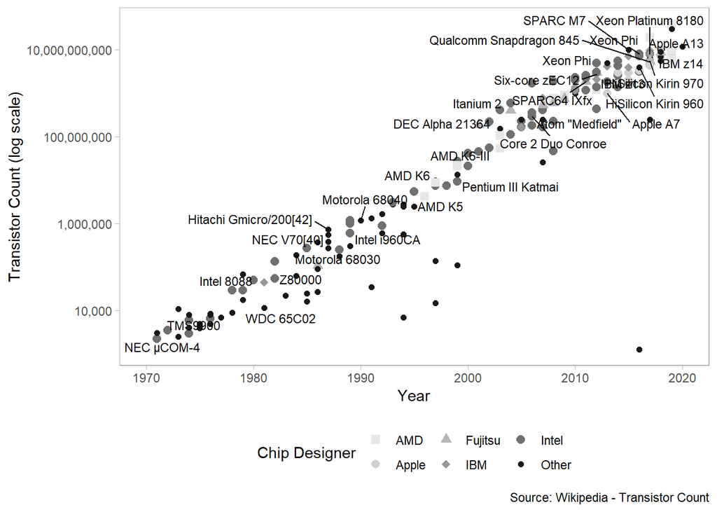

### Chapter 32: What did The Economist get spectacularly wrong? Africa after 2000

Share of countries with any bad policy

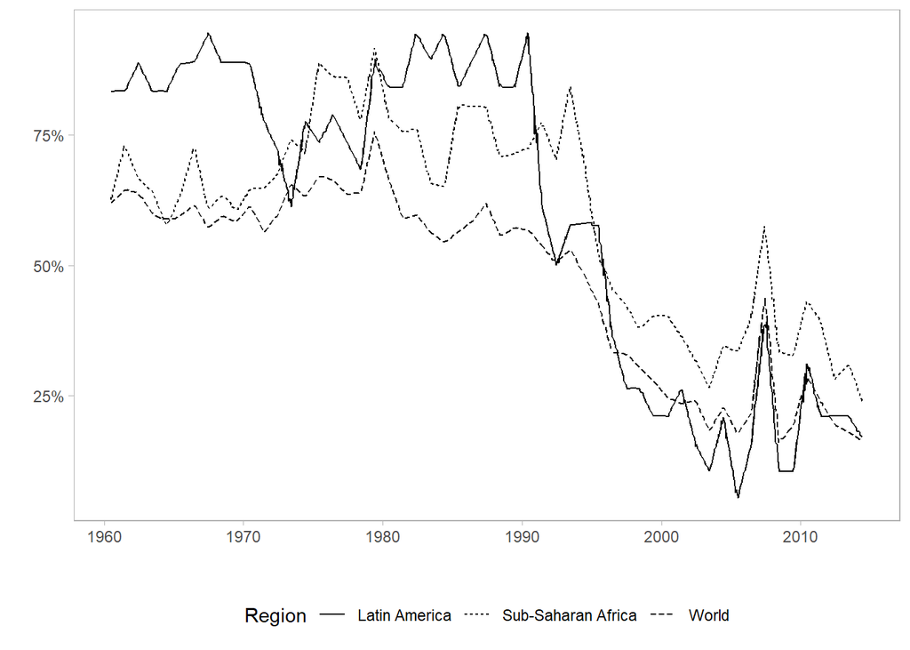

Share of deaths from HIV/AIDS, 2000

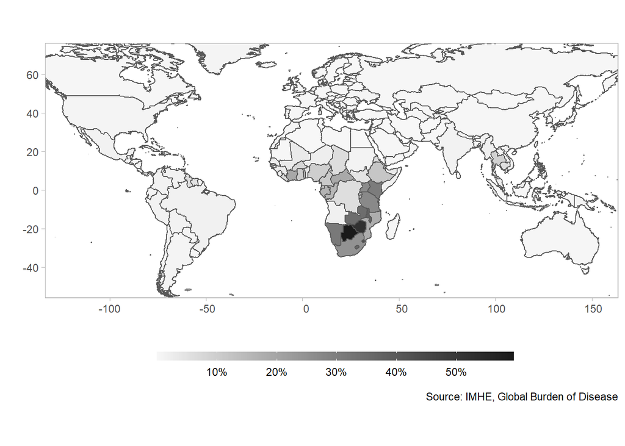